# CA2 - Genetic and Games Algorithm

**Amirhosein Sabahi - 810101556**

# Genetic Algorithm

## Imports

```python
from bisect import bisect_left
from dataclasses import dataclass
from itertools import accumulate
from random import randrange, random, uniform
from typing import List, Tuple

import matplotlib.pyplot as plt
import numpy as np
from PIL import Image
from tqdm import tqdm
```

```python
class ImageAnalysis:
    def __init__(self, image: Image, rows: int, columns: int):
        self._image = image
        self._rows = rows
        self._columns = columns
        self._pieces = self._split_image()
        self._dissimilarity_matrix = self._calculate_dissimilarity_matrix()

    @property
    def pieces(self) -> dict:
        return self._pieces

    def get_dissimilarity(self, ids: tuple, orientation: str) -> float:
        return self._dissimilarity_matrix[ids][orientation]

    def _split_image(self) -> dict:
        width, height = self._image.size
        piece_width = width // self._columns
        piece_height = height // self._rows

        pieces = {}
        for i in range(self._rows):
            for j in range(self._columns):
                left = j * piece_width
                top = i * piece_height
                right = left + piece_width
                bottom = top + piece_height
                piece = self._image.crop((left, top, right, bottom))
                pieces[i * self._columns + j] = piece
        return pieces

    def _calculate_dissimilarity_matrix(self) -> dict:
        matrix = {}
        for i in range(self._rows * self._columns):
            for j in range(self._rows * self._columns):
                if i == j:
                    continue
                matrix[i, j] = {
                    "L-R": self._dissimilarity_measure(self._pieces[i], self._pieces[j], "L-R"),
                    "T-D": self._dissimilarity_measure(self._pieces[i], self._pieces[j], "T-D"),
                }
        return matrix

    def _dissimilarity_measure(self, piece1: Image, piece2: Image, orientation: str) -> float:
        a = np.asarray(piece1.convert("RGB"), dtype=np.float32)
        b = np.asarray(piece2.convert("RGB"), dtype=np.float32)
        if orientation == "L-R":
             edge_a = a[:, -1:, :]
             edge_b = b[:, :1, :]
        elif orientation == "T-D":
             edge_a = a[-1:, :, :]
             edge_b = b[:1, :, :]
        else:
            raise ValueError("orientation must be 'L-R' or 'T-D'")
        return float(np.sum((edge_a - edge_b) ** 2))
```

## Image Analysis

### ImageAnalysis Class

The `ImageAnalysis` class is responsible for two main tasks:

1. **Splitting the Image**: It takes the source image and splits it into a grid of smaller puzzle pieces.
2. **Calculating Dissimilarity**: It computes a "dissimilarity matrix," which stores a score of how well any two pieces fit together. This is crucial for the genetic algorithm's fitness function.

You will need to implement the `_dissimilarity_measure` method, which is the core of the analysis. The rest of the class is provided for you.

### Task: Implement the `dissimilarity_measure` Method

The `dissimilarity_measure` method calculates how different two puzzle pieces are when placed next to each other. This is a key part of the fitness function, as it determines how well pieces fit together.

#### What You Need to Do:

- **Implement the `_dissimilarity_measure` method** in the `ImageAnalysis` class.
- The method should take two `PIL.Image` objects (`piece1`, `piece2`) and an `orientation` string (`"L-R"` for left-right or `"T-D"` for top-down).
- It should return a single `float` value representing the dissimilarity.

#### Hints:

1. **Convert Images to NumPy Arrays**: Use `np.asarray(piece)` to convert the `PIL.Image` objects into NumPy arrays. This makes it easier to perform mathematical operations on the pixel data.
2. **Extract Edges**: Depending on the `orientation`, you need to extract the pixels from the touching edges of the two pieces.
   - For `"L-R"` (Left-Right), you need the **right edge of `piece1`** and the **left edge of `piece2`**.
   - For `"T-D"` (Top-Down), you need the **bottom edge of `piece1`** and the **top edge of `piece2`**.
3. **Calculate Dissimilarity**: The dissimilarity can be calculated as the **sum of squared differences** between the pixel values of the two edges. The formula is:

   ```
   dissimilarity = sum((edge1 - edge2)^2)
   ```

   You can use `np.sum()` and basic arithmetic operations on the NumPy arrays to compute this value.

## Size Detector

```python
class SizeDetector:
    def __init__(self, image: Image):
        self._image = image

    def detect(self) -> tuple:
        width, height = self._image.size
        aspect_ratio = width / height

        for i in range(1, int(width**0.5) + 1):
            if width % i == 0:
                j = width // i
                if abs(j / i - aspect_ratio) < 0.1:  # Heuristic for aspect ratio
                    return (i, j) if width > height else (j, i)
        return (1, width) # Fallback
```

## Size Detector

### SizeDetector Class

This class is provided to you and does not require any modifications. You can use it to get the piece size before starting the genetic algorithm.

## Individual

### Task: Implement the `Individual` Class

The `Individual` class represents a possible solution to the jigsaw puzzle. It stores the puzzle pieces and evaluates how well they fit together. You will need to implement several parts of this class to calculate the fitness and manage the puzzle pieces.

#### 1. Fitness Calculation (`fitness` property)

- **What You Need to Do**:
  - Implement the `fitness` property to calculate how well the pieces fit together.
  - The fitness value should be based on how the pieces align (i.e., their edges) both horizontally and vertically.
  - The fitness function should return an inverse fitness value based on the dissimilarities between adjacent pieces.

  **Hint**:
  - Use the `ImageAnalysis.get_dissimilarity(ids, orientation)` function to get the dissimilarity between adjacent pieces.
  - Calculate the dissimilarity between adjacent pieces both **horizontally** and **vertically** (Left-Right and Top-Down).

#### 2. Core Methods (`__init__`, `piece_size`, `piece_by_id`)

- **What You Need to Do**:
  - Implement the `__init__` method to initialize the puzzle with pieces and store the number of rows and columns.
  - Implement the `piece_size()` method to return the size of a single piece.
  - Implement the `piece_by_id()` method to retrieve a piece by its unique ID.

#### Parts You **Do Not Need to Implement**:

- **`edge` Method**:
  - This method checks the neighboring piece's ID based on orientation (top, right, bottom, left). It is useful for advanced puzzle assembly but is **not necessary** for this task. You can **skip** implementing this method.
- **`to_image` Method**:
  - This method reassembles the individual puzzle into a complete image. It is used for **visualization** of the solution and is **not required** for fitness evaluation. You can **skip** implementing this method.

```python
class Individual:
    def __init__(self, pieces: dict, rows: int, columns: int, initial_state: List[int] = None):
        self._pieces = pieces
        self._rows = rows
        self._columns = columns
        n = rows * columns
        if initial_state is None:
            perm = np.random.permutation(n).tolist()
        else:
            if len(initial_state) != n:
                raise ValueError("initial_state length mismatch")
            perm = list(initial_state)
        self._chromosome = np.array(perm, dtype=int).reshape(rows, columns)

    @property
    def fitness(self) -> float:
         total = 0.0
         for i in range(self._rows):
            for j in range(self._columns - 1):
                a = int(self._chromosome[i, j])
                b = int(self._chromosome[i, j + 1])
                total += image_analysis.get_dissimilarity((a, b), "L-R")
         for i in range(self._rows - 1):
            for j in range(self._columns):
                a = int(self._chromosome[i, j])
                b = int(self._chromosome[i + 1, j])
                total += image_analysis.get_dissimilarity((a, b), "T-D")
         return 1.0 / (total + 1e-9)

    def piece_size(self) -> tuple:
        any_piece = next(iter(self._pieces.values()))
        w, h = any_piece.size
        return w, h

    def piece_by_id(self, piece_id: int) -> Image:
         return self._pieces[piece_id]

    def to_image(self) -> Image:
        """Reassembles the individual into a single image."""
        piece_width, piece_height = self.piece_size()
        canvas_width = self._columns * piece_width
        canvas_height = self._rows * piece_height
        canvas = Image.new('RGB', (canvas_width, canvas_height))

        for i in range(self._rows):
            for j in range(self._columns):
                piece_id = self._chromosome[i, j]
                piece = self.piece_by_id(piece_id)
                canvas.paste(piece, (j * piece_width, i * piece_height))
        return canvas

    def __getitem__(self, key):
        return self._chromosome[key]

    def __repr__(self):
        return f"Individual(fitness={self.fitness})"
```

## Selection

### Task: Implement the `roulette_selection` Function

The **roulette selection** process is part of the genetic algorithm and is used to select pairs of individuals from the population based on their **fitness**. The fitter individuals are more likely to be selected for reproduction, but all individuals still have a chance of being selected, even if their fitness is low.

#### **Hints**:

- You can use `random.uniform(0, total_sum)` to generate a random number between 0 and the total fitness sum.
- The `bisect_left` function helps find the position in the probability intervals where the random number fits.
- The **elites** are guaranteed to move to the next generation without crossover, so they should be excluded from the random selection process.

### Task: Implement Another Selection Method

Besides `roulette_selection`, there are other selection strategies. Implement one of the following:

1. **Tournament Selection**:
   - Randomly select a few individuals (a "tournament").
   - The individual with the best fitness in the tournament is chosen as a parent.
   - Repeat to select the second parent.
2. **Rank Selection**:
   - Rank the individuals by fitness.
   - Selection probability is based on rank, not fitness value. This can prevent premature convergence.

```python
import random as rnd
from bisect import bisect_left

def roulette_selection(population: List[Individual], elite_size: int) -> List[Tuple[Individual, Individual]]:
    n = len(population)
    if n <= elite_size:
        return []
    pop_sorted = sorted(population, key=lambda ind: ind.fitness, reverse=True)
    pool = pop_sorted[elite_size:]
    fits = [max(0.0, ind.fitness) for ind in pool]
    total = sum(fits)

    if total == 0.0:
        def pick_one():
            return rnd.choice(pool)
    else:
        cum = []
        s = 0.0
        for f in fits:
            s += f
            cum.append(s)
        def pick_one():
            r = rnd.uniform(0.0, cum[-1])
            i = bisect_left(cum, r)
            return pool[i]

    pairs_needed = (max(n - elite_size, 0) + 1) // 2
    pairs = []
    for _ in range(pairs_needed):
        a = pick_one()
        b = pick_one()
        pairs.append((a, b))
    return pairs

def your_other_selection_method(population: List[Individual], elite_size: int, tournament_size: int = 3) -> List[Tuple[Individual, Individual]]:
    n = len(population)
    if n <= elite_size:
        return []
    pop_sorted = sorted(population, key=lambda ind: ind.fitness, reverse=True)
    pool = pop_sorted[elite_size:]

    def tour_pick():
        cand = rnd.sample(pool, k=min(tournament_size, len(pool)))
        return max(cand, key=lambda ind: ind.fitness)

    pairs_needed = (max(n - elite_size, 0) + 1) // 2
    pairs = []
    for _ in range(pairs_needed):
        a = tour_pick()
        b = tour_pick()
        pairs.append((a, b))
    return pairs
```

## Crossover

### Task: Implement the Crossover Logic

Crossover is where the "genetic" part of the algorithm happens. You'll create a new "child" individual by combining the traits of two "parent" individuals. The goal is to build a better-assembled puzzle by picking the best-fitting pieces from the parents.

This crossover strategy is complex. It starts with a random piece and then iteratively adds adjacent pieces based on a priority system.

#### Crossover Priority System:

1. **Shared Pieces (Highest Priority)**: If two parents agree on a neighboring piece, that piece is chosen. This is a strong indicator of a correct fit.
2. **Buddy Pieces (Medium Priority)**: A "buddy piece" is a pair of pieces that are each other's best match. If one of these is a neighbor, it's a good candidate.
3. **Best Match (Lowest Priority)**: If neither of the above is found, choose the piece that has the lowest dissimilarity score (the best fit) from the remaining pieces.

#### Your Tasks:

1. **Implement Piece Selection Methods**:
   - `_get_shared_piece()`: Find pieces that are neighbors in **both** parents.
   - `_get_buddy_piece()`: Find "buddy" pieces (mutual best friends).
   - `_get_best_match_piece()`: Find the piece with the best dissimilarity score among the available pieces.
2. **Implement the `Crossover` Class**:
   - Use a `heapq` (min-heap) to manage candidate pieces based on the priority system.
   - Implement the `run()` method to build the child's chromosome by selecting from the candidates.
   - You can create different versions of the `add_piece_candidate` method to experiment with different strategies (e.g., one using only shared and best-match pieces, and another using all three).
3. **Experiment and Compare**:
   - After implementing the `Crossover` class, you can create variations of it. For example, one version might only use "shared" and "best match" pieces, while another could use all three priorities.
   - Compare how these different crossover strategies affect the speed and quality of the solution. Does including "buddy pieces" help? Is it worth the extra computation?

```python
import heapq

SHARED_PIECE_PRIORITY = -10
BUDDY_PIECE_PRIORITY = -1

def complementary_orientation(orientation):
    return {"T": "D", "R": "L", "D": "T", "L": "R"}.get(orientation)

class Crossover:
    def __init__(self, parent1: Individual, parent2: Individual, analysis: ImageAnalysis):
        self._parents = (parent1, parent2)
        self._analysis = analysis
        self._pieces_length = len(parent1._pieces)
        self._child_rows = parent1._rows
        self._child_columns = parent1._columns
        self._kernel = {}
        self._taken_positions = set()
        self._candidate_pieces = []
        self._min_row, self._max_row, self._min_column, self._max_column = 0, 0, 0, 0

    def run(self):
     self._initialize_kernel()
     while not self._is_kernel_full():
        if not self._candidate_pieces:
            for pid, pos in list(self._kernel.items()):
                self._update_candidate_pieces(pid, pos)
            if not self._candidate_pieces:
                break
        priority, (position, pid), _ = heapq.heappop(self._candidate_pieces)
        if position in self._taken_positions or pid in self._kernel or not self._is_in_range(position):
            continue
        self._put_piece_to_kernel(pid, position)
        return self.child()

    def child(self) -> 'Individual':
        ids = [None] * self._pieces_length

        for piece_id, (row, column) in self._kernel.items():
           index = (row - self._min_row) * self._child_columns + (column - self._min_column)
           ids[index] = piece_id

        used_ids = {pid for pid in ids if pid is not None}
        all_ids = list(self._parents[0]._pieces.keys())
        unused_ids = [pid for pid in all_ids if pid not in used_ids]

        it = iter(unused_ids)
        for i in range(self._pieces_length):
            if ids[i] is None:
                ids[i] = next(it)
        return Individual(self._parents[0]._pieces, self._child_rows, self._child_columns, initial_state=ids)



    def _initialize_kernel(self):
        # This method is provided. It selects a random starting piece.
        root_piece_id = list(self._parents[0]._pieces.keys())[randrange(self._pieces_length)]
        self._put_piece_to_kernel(root_piece_id, (0, 0))

    def _put_piece_to_kernel(self, piece_id: int, position: tuple):
        # This method is provided. It adds a piece to the solution kernel.
        self._kernel[piece_id] = position
        self._taken_positions.add(position)
        self._update_candidate_pieces(piece_id, position)

    def _update_candidate_pieces(self, piece_id: int, position: tuple):
        # This method is provided. It finds available boundaries and adds new candidates.
        for orientation, pos in self._available_boundaries(position):
            self.add_piece_candidate(piece_id, orientation, pos)

    def add_piece_candidate(self, piece_id: int, orientation: str, position: tuple):
     shared = self._get_shared_piece(piece_id, orientation)
     if self._is_valid_piece(shared):
        self._add_candidate_to_heap(SHARED_PIECE_PRIORITY, shared, position, (piece_id, orientation))
        return
     buddy = self._get_buddy_piece(piece_id, orientation)
     if self._is_valid_piece(buddy):
        self._add_candidate_to_heap(BUDDY_PIECE_PRIORITY, buddy, position, (piece_id, orientation))
        return
     best_id, best_score = self._get_best_match_piece(piece_id, orientation)
     if self._is_valid_piece(best_id):
        self._add_candidate_to_heap(best_score, best_id, position, (piece_id, orientation))

    def _get_shared_piece(self, piece_id: int, orientation: str) -> int:
     def neighbor_in_parent(parent):
        grid = parent._chromosome
        pr, pc = None, None
        for r in range(parent._rows):
            for c in range(parent._columns):
                if int(grid[r, c]) == piece_id:
                    pr, pc = r, c
                    break
            if pr is not None:
                break
        if pr is None:
            return None
        drdc = {"T": (-1, 0), "R": (0, 1), "D": (1, 0), "L": (0, -1)}
        dr, dc = drdc[orientation]
        rr, cc = pr + dr, pc + dc
        if 0 <= rr < parent._rows and 0 <= cc < parent._columns:
            return int(grid[rr, cc])
        return None
     n1 = neighbor_in_parent(self._parents[0])
     n2 = neighbor_in_parent(self._parents[1])
     if n1 is not None and n1 == n2 and n1 not in self._kernel:
        return n1
     return None

    def _get_buddy_piece(self, piece_id: int, orientation: str) -> int:
     remaining = [pid for pid in self._parents[0]._pieces.keys() if pid not in self._kernel and pid != piece_id]
     if not remaining:
        return None

     def orient_ids(ori, a, b):
        if ori == "R": return "L-R", (a, b)
        if ori == "L": return "L-R", (b, a)
        if ori == "D": return "T-D", (a, b)
        if ori == "T": return "T-D", (b, a)

     best_b, best_s = None, float("inf")
     for cid in remaining:
        o, (a, b) = orient_ids(orientation, piece_id, cid)
        s = self._analysis.get_dissimilarity((a, b), o)
        if s < best_s:
            best_b, best_s = cid, s
     if best_b is None:
        return None

     rev = complementary_orientation(orientation)
     best_back, best_back_s = None, float("inf")
     for cid in [piece_id] + [x for x in remaining if x != best_b]:
        o, (a, b) = orient_ids(rev, best_b, cid)
        s = self._analysis.get_dissimilarity((a, b), o)
        if s < best_back_s:
            best_back, best_back_s = cid, s

     if best_back == piece_id:
        return best_b
     return None

    def _get_best_match_piece(self, piece_id: int, orientation: str) -> tuple:
        remaining = [pid for pid in self._parents[0]._pieces.keys() if pid not in self._kernel and pid != piece_id]
        if not remaining:
         return None, float("inf")

        def orient_ids(ori, a, b):
         if ori == "R": return "L-R", (a, b)
         if ori == "L": return "L-R", (b, a)
         if ori == "D": return "T-D", (a, b)
         if ori == "T": return "T-D", (b, a)

        best_id, best_score = None, float("inf")
        for cid in remaining:
         o, (a, b) = orient_ids(orientation, piece_id, cid)
         s = self._analysis.get_dissimilarity((a, b), o)
         if s < best_score:
            best_id, best_score = cid, s
        return best_id, best_score

    def _add_candidate_to_heap(self, priority: int, piece_id: int, position: tuple, relative_piece: tuple):
        # This is a helper to push candidates to the heap.
        heapq.heappush(self._candidate_pieces, (priority, (position, piece_id), relative_piece))

    # The following helper methods for boundary checks are provided for you.
    def _available_boundaries(self, row_and_column):
        (row, column) = row_and_column
        boundaries = []
        if not self._is_kernel_full():
            positions = {"T": (row - 1, column), "R": (row, column + 1), "D": (row + 1, column), "L": (row, column - 1)}
            for orientation, position in positions.items():
                if position not in self._taken_positions and self._is_in_range(position):
                    self._update_kernel_boundaries(position)
                    boundaries.append((orientation, position))
        return boundaries

    def _is_kernel_full(self):
        return len(self._kernel) == self._pieces_length

    def _is_in_range(self, pos):
        return self._is_row_in_range(pos[0]) and self._is_column_in_range(pos[1])

    def _is_row_in_range(self, row):
        return abs(min(self._min_row, row)) + abs(max(self._max_row, row)) < self._child_rows

    def _is_column_in_range(self, col):
        return abs(min(self._min_column, col)) + abs(max(self._max_column, col)) < self._child_columns

    def _update_kernel_boundaries(self, pos):
        self._min_row, self._max_row = min(self._min_row, pos[0]), max(self._max_row, pos[0])
        self._min_column, self._max_column = min(self._min_column, pos[1]), max(self._max_column, pos[1])

    def _is_valid_piece(self, piece_id):
        return piece_id is not None and piece_id not in self._kernel
```

## Mutation

```python
def mutation(individual: Individual, mutation_rate: float = 0.01) -> Individual:
    n = individual._rows * individual._columns
    perm = individual._chromosome.flatten().tolist()
    for i in range(n):
        if rnd.random() < mutation_rate:
            j = rnd.randrange(n)
            perm[i], perm[j] = perm[j], perm[i]
    return Individual(individual._pieces, individual._rows, individual._columns, perm)
```

## Genetic Algorithm

### Task: Implement the `GeneticAlgorithm` Class

This class simulates the process of evolution to solve the jigsaw puzzle using a **Genetic Algorithm**.

The genetic algorithm involves selection, crossover, and mutation processes to evolve better solutions over time.

```python
from dataclasses import dataclass
from PIL import Image

def crop_to_multiple(img: Image.Image, ps: int) -> Image.Image:
    w, h = img.size
    w2 = (w // ps) * ps
    h2 = (h // ps) * ps
    left = (w - w2) // 2
    top  = (h - h2) // 2
    return img.crop((left, top, left + w2, top + h2))

@dataclass
class GeneticAlgorithm:
    image_path: str
    population_size: int
    generations: int
    elite_size: int
    mutation_rate: float
    selection_method: callable
    crossover_method: callable
    piece_size: int
    score_function: callable = None

    def run(self) -> "Individual":
        img = Image.open(self.image_path).convert("RGB")
        ps = self.piece_size

        if (img.size[0] % ps) != 0 or (img.size[1] % ps) != 0:
         img = crop_to_multiple(img, ps)

        w, h = img.size
        rows, columns = h // ps, w // ps

        analysis = ImageAnalysis(img, rows, columns)
        global image_analysis
        image_analysis = analysis

        population = [Individual(analysis.pieces, rows, columns) for _ in range(self.population_size)]
        score = self.score_function or (lambda ind: ind.fitness)

        for _ in range(self.generations):
            population.sort(key=score, reverse=True)
            next_gen = population[: self.elite_size]
            pairs = self.selection_method(population, self.elite_size)
            children = []
            for p1, p2 in pairs:
                co = self.crossover_method(p1, p2, analysis)
                child = co.run() if hasattr(co, "run") else co
                child = mutation(child, self.mutation_rate)
                children.append(child)
            need = self.population_size - len(next_gen)
            next_gen.extend(children[:max(0, need)])
            while len(next_gen) < self.population_size:
                next_gen.append(Individual(analysis.pieces, rows, columns))
            population = next_gen

        population.sort(key=score, reverse=True)
        return population[0]
```

## Running the Algorithm

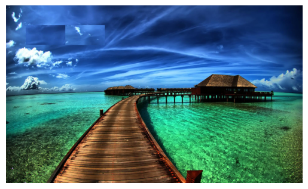

```python
import matplotlib.pyplot as plt

def crossover_factory(p1, p2, analysis):
    return Crossover(p1, p2, analysis)

ga = GeneticAlgorithm(
    image_path=r"F:\Term7\AI\Ai\images\island.jpg",
    population_size=100,
    generations=10,
    elite_size=10,
    piece_size=128,
    mutation_rate=0.01,
    selection_method=roulette_selection,
    crossover_method=Crossover,
    score_function=None
)
best_solution = ga.run()

img_out = best_solution.to_image()
plt.imshow(img_out)
plt.axis("off")
plt.show()

img_out.save("best_solution.png")
```

```python
import os, time, pathlib, math
from typing import Optional
from PIL import Image
import pandas as pd

IMAGES = [
    r"F:\Term7\AI\Ai\images\lion.jpg"
]
PIECE_SIZES = [32, 64, 128]
GENERATIONS = [10, 15, 20]
POPULATION = 100
ELITE = 10
MUT_RATE = 0.01

OUT_DIR = pathlib.Path("./ga_outputs")
(OUT_DIR / "tmp").mkdir(parents=True, exist_ok=True)

def crop_to_multiple(img: Image.Image, ps: int) -> Image.Image:
    w, h = img.size
    w2 = (w // ps) * ps
    h2 = (h // ps) * ps
    left = (w - w2) // 2
    top  = (h - h2) // 2
    return img.crop((left, top, left + w2, top + h2))

def ensure_divisible_path(img_path: str, ps: int) -> str:
    try:
        img = Image.open(img_path)
    except Exception:
        return img_path
    w, h = img.size
    if (w % ps) == 0 and (h % ps) == 0:
        return img_path
    img2 = crop_to_multiple(img, ps)
    tmp_path = OUT_DIR / "tmp" / f"{pathlib.Path(img_path).stem}_ps{ps}_cropped.png"
    img2.save(tmp_path.as_posix())
    return tmp_path.as_posix()

summary_rows = []

for img_path in IMAGES:
    img_name = pathlib.Path(img_path).stem
    for ps in PIECE_SIZES:
        use_path = ensure_divisible_path(img_path, ps)
        for gens in GENERATIONS:
            t0 = time.perf_counter()
            try:
                ga = GeneticAlgorithm(
                    image_path=use_path,
                    population_size=POPULATION,
                    generations=gens,
                    elite_size=ELITE,
                    piece_size=ps,
                    mutation_rate=MUT_RATE,
                    selection_method=roulette_selection,
                    crossover_method=Crossover,
                    score_function=None
                )
                best = ga.run()
                dt = time.perf_counter() - t0
                fit = float(best.fitness)
                print(f"{img_name:12s} | piece_size={ps:3d} | gens={gens:2d} | fitness={fit:12.4f} | time={dt:7.2f}s")

                try:
                    out_img = best.to_image()
                    out_file = OUT_DIR / f"{img_name}_ps{ps}_gen{gens}.png"
                    out_img.save(out_file.as_posix())
                except Exception as e:
                    print(f"save skipped: {e}")

                summary_rows.append({
                    "image": img_name,
                    "piece_size": ps,
                    "generations": gens,
                    "fitness": fit,
                    "time_sec": dt
                })

            except Exception as e:
                dt = time.perf_counter() - t0
                print(f"{img_name:12s} | piece_size={ps:3d} | gens={gens:2d} | ERROR: {e} | time={dt:7.2f}s")
                summary_rows.append({
                    "image": img_name,
                    "piece_size": ps,
                    "generations": gens,
                    "fitness": float("nan"),
                    "time_sec": dt,
                    "error": str(e)
                })

df = pd.DataFrame(summary_rows)
if not df.empty:
    display(df.sort_values(["image", "piece_size", "generations"]).reset_index(drop=True))
else:
    print("No results collected.")
```

```
lion         | piece_size= 32 | gens=10 | fitness=      0.0000 | time=  55.40s
lion         | piece_size= 32 | gens=15 | fitness=      0.0000 | time=  49.26s
lion         | piece_size= 32 | gens=20 | fitness=      0.0000 | time=  56.83s
lion         | piece_size= 64 | gens=10 | fitness=      0.0000 | time=   4.67s
lion         | piece_size= 64 | gens=15 | fitness=      0.0000 | time=   5.22s
lion         | piece_size= 64 | gens=20 | fitness=      0.0000 | time=   5.46s
lion         | piece_size=128 | gens=10 | fitness=      0.0000 | time=   0.67s
lion         | piece_size=128 | gens=15 | fitness=      0.0000 | time=   0.70s
lion         | piece_size=128 | gens=20 | fitness=      0.0000 | time=   0.81s
```

|  | image | piece_size | generations | fitness | time_sec |
| --- | --- | --- | --- | --- | --- |
| 0 | lion | 32 | 10 | 2.432628e-08 | 55.402565 |
| 1 | lion | 32 | 15 | 2.801349e-08 | 49.262765 |
| 2 | lion | 32 | 20 | 2.720217e-08 | 56.825014 |
| 3 | lion | 64 | 10 | 5.267509e-08 | 4.674294 |
| 4 | lion | 64 | 15 | 5.507478e-08 | 5.215452 |
| 5 | lion | 64 | 20 | 7.424208e-08 | 5.464436 |
| 6 | lion | 128 | 10 | 1.982095e-07 | 0.674719 |
| 7 | lion | 128 | 15 | 1.982095e-07 | 0.701316 |
| 8 | lion | 128 | 20 | 1.982095e-07 | 0.807868 |

## Report

[ImageAnalysis._dissimilarity_measure]

این بخش لبه‌های دو قطعه را بر اساس جهت مقایسه می‌کند: برای چپ–راست، ستون آخر قطعه اول با ستون اول قطعه دوم، و برای بالا–پایین، ردیف آخر قطعه اول با ردیف اول قطعه دوم برداشته می‌شود. هر دو لبه به آرایه عددی تبدیل می‌شود، اختلاف پیکسلی عنصر به عنصر گرفته و مربع اختلاف‌ها جمع می‌شود تا مقدار عدم‌شباهت به دست آید. این مقدار هرچه کمتر باشد نشان‌دهنده چسبندگی بهتر دو قطعه است و بعدها مستقیماً در محاسبه سازگاری استفاده می‌شود.

[Individual.init]

در سازنده فرد، نگاشت شناسه‌قطعه به تصویر ذخیره می‌شود، تعداد ردیف و ستون نگه داشته می‌شود و اگر حالت اولیه داده نشده باشد، یک جایگشت تصادفی از شناسه‌ها ساخته و به ماتریس ردیف×ستون تبدیل می‌شود تا هر جایگاه در شبکه یک شناسه داشته باشد. این ساختار همان کروموزوم فرد است که نقشه چیدمان را کد می‌کند.

[Individual.piece_size]

این متد با خواندن یکی از قطعات، اندازه آن را برمی‌گرداند تا سایر بخش‌ها مثل تبدیل آرایش به تصویر نهایی بتوانند ابعاد بوم را درست محاسبه کنند. خروجی شامل عرض و ارتفاع یک قطعه است.

[Individual.piece_by_id]

این تابع دسترسی سریع به تصویر قطعه از روی شناسه را فراهم می‌کند. از نگاشت داخلی قطعه‌ها استفاده می‌کند تا سایر بخش‌ها (نمایش تصویر نهایی یا محاسبات) بدون جست‌وجوی اضافی قطعه را بگیرند.

[Individual.fitness]

در این ویژگی، تمام مرزهای مجاور در آرایش فعلی بررسی می‌شود: مرزهای افقی بین هر جفت همسایه در یک ردیف و مرزهای عمودی بین هر جفت همسایه در یک ستون. برای هر مرز از تحلیل تصویر، مقدار عدم‌شباهت خوانده و جمع می‌شود. سازگاری به صورت معکوس این جمع بازگردانده می‌شود تا آرایش‌هایی که مرزهایشان بهتر می‌چسبد امتیاز بزرگ‌تری بگیرند.

[selection.roulette_selection]

در انتخاب چرخ رولت، ابتدا جمع سازگاری‌های جمعیت محاسبه می‌شود، سپس با تشکیل مجموع‌های تجمعی، برای هر والد یک عدد تصادفی بین صفر تا جمع کل گرفته می‌شود و فردی که بازه‌اش آن عدد را پوشش می‌دهد انتخاب می‌گردد. افراد نخبه از استخر تصادفی حذف می‌شوند تا مستقیم به نسل بعد بروند. این روش احتمال انتخاب را متناسب با سازگاری فرد تنظیم می‌کند.

در این پازلِ جایگشتی، چرخ‌رولت وقتی پراکندگی سازگاری بالاست سریع‌تر جمعیت را به سمت طرح‌های بهتر می‌برد، اما به «مقیاس‌پذیری» حساس است: اگر سازگاری‌ها نزدیک یا خیلی نامتوازن باشند، انتخاب یا شبه‌تصادفی می‌شود یا بیش‌ازحد روی چند فرد متمرکز؛ نتیجه معمولاً افت تنوع و خطر همگرایی زودرس، مخصوصاً روی الگوهای تکراری و فلات‌های سازگاری. نقطه قوت پیاده‌سازی شما این است که در مجموعِ صفر، به انتخاب یکنواخت برمی‌گردد و از بن‌بست خارج می‌شود، اما همچنان به تنظیم دقیق نخبه‌ها و نرخ جهش نیاز دارد.

[selection.your_other_selection_method]

در انتخاب تورنمنت، هر بار چند فرد به طور تصادفی برداشته می‌شوند و بهترین آن‌ها به عنوان والد برگزیده می‌شود. این کار تا پر شدن تعداد جفت‌ها تکرار می‌شود. مزیت آن این است که علاوه بر افراد خیلی خوب، به افراد متوسط نیز شانس بقا می‌دهد و تنوع جمعیت بهتر حفظ می‌شود.

تورنمنت با اندازه‌ی کوچک فشار انتخاب را پایدار و قابل‌تنظیم نگه می‌دارد؛ افراد متوسط هم گهگاه والد می‌شوند، بلوک‌های محلی زود نابود نمی‌شوند و تنوع دیرتر فرو می‌ریزد. معمولاً آهنگ همگرایی کمی آهسته‌تر از چرخ‌رولت است اما احتمال گیرکردن روی جواب‌های محلی کمتر و بهترین سازگاری نهایی در اجراهای متعدد باثبات‌تر است. جمع‌بندی عملی: آغاز کار با تورنمنتِ کوچک برای حفظ تنوع، و در میانه‌ی مسیر با بهبود تفکیک سازگاری، افزایش ملایم اندازه تورنمنت یا سهم نخبه‌ها؛ یا ترکیبِ دو روش برای جمعِ سرعت و پایداری.

[mutation]

در جهش، با احتمالی برابر نرخ جهش، دو جایگاه تصادفی از کروموزوم با هم جابه‌جا می‌شوند. این ساده‌ترین حرکت معتبر روی فضای جایگشت است که بدون تولید تکرار، تنوع را افزایش می‌دهد و امکان خروج از راه‌حل‌های محلی را بیشتر می‌کند. خروجی یک فرد جدید با همان ابعاد است.

[Crossover.add_piece_candidate]

[Crossover._get_shared_piece]

این تابع بررسی می‌کند قطعه‌ای که باید کنار قطعه فعلی بنشیند، در هر دو والد در همان جهت همسایه بوده یا نه. اگر هر دو والد بر همسایگی یکسان توافق داشته باشند، شناسه آن قطعه بازگردانده می‌شود تا با بالاترین اولویت امتحان شود.

[Crossover._get_buddy_piece]

در این تابع برای یک جهت مشخص، بهترین جفت یک‌سویه برای قطعه فعلی پیدا می‌شود و سپس کنترل می‌شود که آیا رابطه دوطرفه است یا نه؛ یعنی قطعه دوم هم بهترین جفتش همین قطعه اول باشد. اگر دوطرفه بود، این زوج به عنوان همیار تشخیص داده و بازگردانده می‌شود.

[Crossover._get_best_match_piece]

اگر دو مورد قبلی یافت نشود، این تابع از میان قطعات استفاده‌نشده، آن قطعه‌ای را برمی‌گرداند که کمترین عدم‌شباهت را روی آن مرز دارد. علاوه بر شناسه قطعه، مقدار عدم‌شباهت هم برگردانده می‌شود تا برای اولویت‌دهی دقیق‌تر به کار رود.

## تحلیل نتایج

خروجی هر عکس به ازای جنریشن ها و اندازه قطعه های مختلف در فایل

ga_outputs

قرار دارد

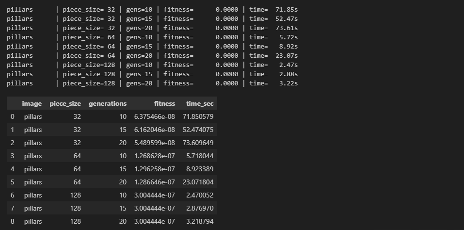

```python
from IPython.display import Image, display
display(Image(filename="images/Screenshot 2025-11-22 180032.png", width=1000))
```

⚠️ Important Note:

Using **NumPy arrays** allows you to perform operations on vectors **more efficiently** and **faster**.

**Avoid using `for` loops** whenever possible, as vectorized operations in NumPy are **optimized for performance** and significantly reduce execution time.

## Questions

Question 1

پازل 6×8 با 48 قطعهِ یکتا ⇒ تعداد تمام چیدمان‌ها

فضای حالت دقیق:

48!

تقریب (بر حسب توان 10): log10(48!) ≈ 61.0939 ⇒ 48! ≈ 1.24 × 10^61

نزدیک‌ترین توان 10: 10^61

Question 2

خیر- زیرا الگوهای تکراری و تقارن بالا باعث می شود که هر خانه فقط سیاه/سفید است و مرزها فقط «سیاه→سفید» یا «سفید→سیاه» هستند؛ پس بسیاری از جفت‌قطعه‌ها عدم‌شباهت تقریباً یکسان دارند.

جایگشت‌های زیادی همان الگوی راه‌راه را حفظ می‌کنند و فیتنس مشابه می‌گیرند؛ جست‌وجو روی فلات می‌افتد و همگرایی سخت می‌شود.

همچنین کراس‌اور جایگشتی با اطلاعات متمایزکننده کم، بخش‌های درست را می‌شکند و پیشرفت به‌صورت تصادفی می‌شود.

Question 3

در مسئلهٔ پازلِ جایگشتی، کروموزوم باید یک جایگشتِ معتبر از قطعات باشد و کیفیت راه‌حل از «همسایگی‌های محلیِ درست» میان قطعات به دست می‌آید، نه از جایگاه خطی ژن‌ها؛ در حالی‌که روش‌های ترکیبِ تک‌نقطه‌ای و دونقطه‌ای

فقط بر اساس برشِ اندیسی عمل می‌کنند، معمولاً فرزندانی با ژن‌های تکراری یا مفقود می‌سازند و ناچار به ترمیم هستند، و حتی پس از ترمیم نیز زوج‌های مفید و نوارهای درستِ محلی از بین می‌رود. این روش‌ها بر پایهٔ فرضِ معنا‌دار

بودنِ جایگاه خطی ژن‌اند، اما در پازل معنا در روابط دو‌بعدی و چسبندگیِ لبه‌هاست؛ بنابراین برشِ ساده، سیگنالِ فیتنس را تضعیف می‌کند، جست‌وجو را کند و تصادفی می‌سازد و به فلات‌های فیتنس می‌انجامد. از این رو باید از کراس

اوورهای سازگار با جایگشت و همسایگی—مانند روش‌های نگاشت یا ترکیب‌های ابتکاری مبتنی بر قطعهٔ مشترک، جفتِ همیار و بهترین‌جفت—استفاده کرد.

Question 4

در حل پازل با الگوریتم ژنتیک، فشار انتخاب بالا—وقتی همواره بهترین‌ها بخش بزرگی از والدین را می‌سازند—به‌سرعت جمعیت را به چند «الگوی غالب» می‌کشاند و ژن‌های جایگزین (چینش‌های متفاوتِ قطعات) حذف می‌شوند؛ در نتیجه

تنوع فرو می‌ریزد، جست‌وجو در همسایگی بسیار کوچکی از فضای حالت گیر می‌کند و همگرایی زودرس روی راه‌حل‌های محلی (مثلاً نوارهایی که به‌ظاهر خوب می‌چسبند ولی تصویر کلی غلط است) رخ می‌دهد. انتخاب تورنمنت با اندازهٔ

تورنمنت کوچک و یا با تورنمنت احتمال‌محور، عمداً به افراد ضعیف‌تر نیز شانس بقا/والد شدن می‌دهد؛ این کار تنوع ژنتیکی را حفظ می‌کند، از سلطهٔ زودهنگام یک طرح اشتباه جلوگیری می‌کند، و با کاوش گسترده‌تر فضای جایگشت‌ها

احتمال کشف ترکیب‌های بهتری از قطعات را بالا می‌برد. در عمل، ترکیب تورنمنتِ کم‌قدرت با کمی جهش، محدود کردن شمار نخبگان، و شاید نگهداری بایگانی متنوع، تعادل مفید میان بهره‌برداری از راه‌حل‌های خوب و اکتشاف چینش‌های

جدید را ایجاد می‌کند.

Question 5

در مسائل جایگشتی مانند پازل، جهشِ جابجاییِ تصادفی دو قطعه ابزار اصلیِ تزریقِ تنوع است؛ بدون نقضِ اعتبارِ جایگشت، مسیرهای تازه‌ای در فضا باز می‌کند، از گیرکردن در مینیمم‌های محلی می‌کاهد و بلوک‌های غلطِ پایدار را

می‌شکند تا ترکیب‌های جدید بررسی شوند. اگر نرخ جهش خیلی پایین باشد، جمعیت سریعاً یکنواخت می‌شود، تنوع از دست می‌رود و الگوریتم به همگرایی زودرس روی جواب‌های محلی دچار می‌شود؛ در نتیجه کیفیت نهایی افت می‌کند.

در مقابل، اگر نرخ جهش خیلی بالا باشد، پیوسته ساختارهای مفید ساخته‌شده توسط انتخاب و کراس‌اور تخریب می‌شوند و الگوریتم عملاً به یک جست‌وجوی تصادفیِ بی‌حافظه (نزدیک به نمونه‌گیری تصادفی یکنواخت) تبدیل می‌شود که

ناکارآمد است. بنابراین، جهش باید تعادلی برقرار کند: آن‌قدر کم نباشد که تنوع از بین برود، و آن‌قدر زیاد نباشد که «بلوک‌های سازنده» نابود شوند

# Dots and Boxes with Minimax Algorithm

In this section, you will implement a **Minimax algorithm with Alpha-Beta pruning** to play the Dots and Boxes game. The game is already implemented, and you only need to focus on the AI agent that uses the Minimax algorithm to make intelligent decisions.

## Imports

```python
import math
import numpy as np

from tkinter import *
from dataclasses import dataclass
from typing import List, Optional, Tuple
```

### **Dots and Boxes** is a classic two-player game where:

- Players take turns connecting adjacent dots with horizontal or vertical lines
- When a player completes the fourth side of a box, they score a point and get another turn
- The game ends when all lines are drawn, and the player with the most boxes wins

### Your Task

You will implement the **MinimaxAgent** class that uses:

1. **Minimax Algorithm**: A decision-making algorithm that explores the game tree to find the optimal move
2. **Alpha-Beta Pruning**: An optimization technique that reduces the number of nodes evaluated in the game tree
3. **Evaluation Function**: A heuristic to estimate the value of non-terminal game states

**Important**: You **MUST** implement Alpha-Beta pruning. This is a required optimization that significantly improves the algorithm's performance.

## GameState Class

The `GameState` class represents the current state of the game. It is **provided for you** and includes:

- `board_status`: Tracks how many edges each box has (values from 0-4)
- `row_status`: Tracks which horizontal edges are drawn
- `col_status`: Tracks which vertical edges are drawn
- `player1_turn`: Boolean indicating whose turn it is

### Key Methods (Already Implemented):

- `clone()`: Creates a copy of the game state
- `is_gameover()`: Checks if the game has ended
- `get_scores()`: Returns the current scores for both players
- `available_moves()`: Returns list of all valid moves
- `apply_move()`: Applies a move and returns whether a box was completed

```python
@dataclass
class GameState:
    board_status: np.ndarray  # shape (n-1, n-1)
    row_status: np.ndarray    # shape (n, n-1)
    col_status: np.ndarray    # shape (n-1, n)
    player1_turn: bool

    def clone(self) -> "GameState":
        """Creates a deep copy of the current game state."""
        return GameState(
            board_status=self.board_status.copy(),
            row_status=self.row_status.copy(),
            col_status=self.col_status.copy(),
            player1_turn=self.player1_turn,
        )

    def get_dimensions(self) -> int:
        """Returns the number of dots (n) in the game grid."""
        return self.row_status.shape[0]

    def is_gameover(self) -> bool:
        """Checks if all edges have been drawn."""
        return (self.row_status == 1).all() and (self.col_status == 1).all()

    def get_scores(self) -> Tuple[int, int]:
        """Returns (player1_score, player2_score)."""
        p1 = int(np.count_nonzero(self.board_status == -4))
        p2 = int(np.count_nonzero(self.board_status == 4))
        return p1, p2

    def available_moves(self) -> List[Tuple[str, List[int]]]:
        """Returns a list of all valid moves as (move_type, [row, col])."""
        moves = []
        for c in range(self.row_status.shape[0]):
            for r in range(self.row_status.shape[1]):
                if self.row_status[c, r] == 0:
                    moves.append(("row", [r, c]))

        for c in range(self.col_status.shape[0]):
            for r in range(self.col_status.shape[1]):
                if self.col_status[c, r] == 0:
                    moves.append(("col", [r, c]))

        return moves

    def apply_move(self, move_type: str, logical_position: List[int]) -> bool:
        """
        Applies a move to the game state.
        Returns True if a box was completed, False otherwise.
        """
        r = logical_position[0]
        c = logical_position[1]
        val = 1
        player_modifier = -1 if self.player1_turn else 1

        scored = False
        n_dots = self.get_dimensions()

        if c < (n_dots - 1) and r < (n_dots - 1):
            cur = abs(self.board_status[c, r]) + val
            self.board_status[c, r] = cur * player_modifier
            if abs(self.board_status[c, r]) == 4:
                scored = True

        if move_type == "row":
            self.row_status[c, r] = 1
            if c >= 1:
                cur = abs(self.board_status[c - 1, r]) + val
                self.board_status[c - 1, r] = cur * player_modifier
                if abs(self.board_status[c - 1, r]) == 4:
                    scored = True

        elif move_type == "col":
            self.col_status[c, r] = 1
            if r >= 1:
                cur = abs(self.board_status[c, r - 1]) + val
                self.board_status[c, r - 1] = cur * player_modifier
                if abs(self.board_status[c, r - 1]) == 4:
                    scored = True

        return scored
```

## MinimaxAgent Class

You are required to implement the core Minimax algorithm with **Alpha-Beta pruning**.

## Task 1: Implement the Evaluation Function

The evaluation function estimates how good a game state is for the AI agent. A good evaluation function considers:

- **Score Difference**: The primary factor (your score vs opponent's score)
- **Strategic Position**: Boxes that are almost complete, control of the board, etc.

You can create your own evaluation function or use a simple one based on score difference.

## Task 2: Implement the Minimax Algorithm with Alpha-Beta Pruning

The minimax algorithm explores the game tree to find the optimal move. **You MUST implement Alpha-Beta pruning** to make it efficient.

### Key Concepts to Implement:

1. **Minimax**:
   - Maximizing player tries to maximize the score
   - Minimizing player tries to minimize the score
   - Recursively evaluate game states to find the best move
2. **Alpha-Beta Pruning** (REQUIRED):
   - Alpha (α): The best value the maximizer can guarantee
   - Beta (β): The best value the minimizer can guarantee
   - If β ≤ α at any point, prune (skip) the remaining branches
   - This dramatically reduces the number of nodes evaluated
3. **Depth Limiting**:
   - Use `max_depth` to limit how far ahead the algorithm looks
   - When depth limit is reached, use the evaluation function

```python
class MinimaxAgent:
    def __init__(self, isPlayer1: bool = False):
        """
        Initialize the Minimax agent.
        Args:
            isPlayer1: True if this agent is Player 1, False if Player 2
        """
        self.isPlayer1 = isPlayer1

    @staticmethod
    def _evaluate(state: "GameState", agentIsPlayer1: bool) -> float:
        p1 = int(getattr(state, "p1_score", getattr(state, "player1_score", 0)))
        p2 = int(getattr(state, "p2_score", getattr(state, "player2_score", 0)))
        my, opp = (p1, p2) if agentIsPlayer1 else (p2, p1)
        bs = getattr(state, "board_status", None)
        threes = int(np.count_nonzero(np.abs(bs) == 3)) if bs is not None else 0
        moves = state.available_moves() if hasattr(state, "available_moves") else []
        my_now = 0
        opp_now = 0
        my_turn_now = (state.player1_turn == agentIsPlayer1)
        for mt, pos in moves:
            s2 = state.clone()
            if s2.apply_move(mt, pos):
                if my_turn_now:
                    my_now += 1
                else:
                    opp_now += 1
        return float(100.0 * (my - opp) + 15.0 * my_now - 12.0 * opp_now - 6.0 * threes)




    @staticmethod
    def _is_maximizing_turn(state: "GameState", agentIsPlayer1: bool) -> bool:
       return bool(state.player1_turn) == bool(agentIsPlayer1)


    @staticmethod
    def _order_moves(state: GameState, moves: List[Tuple[str, List[int]]]) -> List[Tuple[str, List[int]]]:
        """
        Helper method (PROVIDED): Orders moves for better alpha-beta pruning efficiency.
        Prioritizes moves that complete boxes, then safe moves, then risky moves.
        You can use this in your choose_move() and _minimax() methods.
        """
        completing_moves = []
        safe_moves = []
        risky_moves = []

        for move_type, pos in moves:
            test_state = state.clone()
            scored = test_state.apply_move(move_type, pos)

            if scored:
                completing_moves.append((move_type, pos))
            else:
                boxes_at_3 = int(np.count_nonzero(np.abs(test_state.board_status) == 3))
                if boxes_at_3 > int(np.count_nonzero(np.abs(state.board_status) == 3)):
                    risky_moves.append((move_type, pos))
                else:
                    safe_moves.append((move_type, pos))

        return completing_moves + safe_moves + risky_moves



    def choose_move(
        self,
        state: "GameState",
        max_depth: Optional[int] = None,
        ) -> Tuple[Optional[str], Optional[List[int]], float]:
        if state.is_gameover():
            return None, None, self._evaluate(state, self.isPlayer1)

        maximizing = self._is_maximizing_turn(state, self.isPlayer1)
        alpha, beta = -math.inf, math.inf
        best_move: Tuple[Optional[str], Optional[List[int]]] = (None, None)
        best_val = -math.inf if maximizing else math.inf

        moves = self._order_moves(state, state.available_moves())

        for move_type, pos in moves:
            next_state = state.clone()
            scored = next_state.apply_move(move_type, pos)
            if not scored:
                next_state.player1_turn = not next_state.player1_turn
            next_maximizing = self._is_maximizing_turn(next_state, self.isPlayer1)

            val = self._minimax(
                next_state,
                depth=1,
                max_depth=max_depth,
                alpha=alpha,
                beta=beta,
                maximizing=next_maximizing,
            )

            if maximizing:
                if val > best_val:
                    best_val = val
                    best_move = (move_type, pos)
                alpha = max(alpha, best_val)
            else:
                if val < best_val:
                    best_val = val
                    best_move = (move_type, pos)
                beta = min(beta, best_val)

            if beta <= alpha:
                break

        return best_move[0], best_move[1], float(best_val)




    def _minimax(
        self,
        state: "GameState",
        depth: int,
        max_depth: Optional[int],
        alpha: float,
        beta: float,
        maximizing: bool,
        ) -> float:
        if state.is_gameover() or (max_depth is not None and depth >= max_depth):
            return float(self._evaluate(state, self.isPlayer1))

        moves = self._order_moves(state, state.available_moves())

        if maximizing:
            value = -math.inf
            for move_type, pos in moves:
                next_state = state.clone()
                scored = next_state.apply_move(move_type, pos)
                if not scored:
                    next_state.player1_turn = not next_state.player1_turn
                next_max = self._is_maximizing_turn(next_state, self.isPlayer1)
                child_val = self._minimax(
                    next_state,
                    depth + 1,
                    max_depth,
                    alpha,
                    beta,
                    next_max,
                )
                value = max(value, child_val)
                alpha = max(alpha, value)
                if beta <= alpha:
                    break
            return float(value)
        else:
            value = math.inf
            for move_type, pos in moves:
                next_state = state.clone()
                scored = next_state.apply_move(move_type, pos)
                if not scored:
                    next_state.player1_turn = not next_state.player1_turn
                next_max = self._is_maximizing_turn(next_state, self.isPlayer1)
                child_val = self._minimax(
                    next_state,
                    depth + 1,
                    max_depth,
                    alpha,
                    beta,
                    next_max,
                )
                value = min(value, child_val)
                beta = min(beta, value)
                if beta <= alpha:
                    break
            return float(value)
```

## Testing Your Implementation

Once you've implemented the Minimax agent, you can test it by playing against it or watching it play against itself.

### Evaluation Steps

To test if your implementation is working correctly:

1. **Test with small depth limits** (e.g., 2-3) first to ensure correctness
2. **Verify alpha-beta pruning** is working by adding counters to track how many nodes are evaluated
3. **Compare performance**: Without pruning vs with pruning
4. **Test different evaluation functions** and see which performs better

```python
def make_initial_state(number_of_dots: int, player1_starts: bool = True) -> GameState:
    """
    Creates a new game state with an empty board.
    """
    board_status = np.zeros((number_of_dots - 1, number_of_dots - 1), dtype=int)
    row_status = np.zeros((number_of_dots, number_of_dots - 1), dtype=int)
    col_status = np.zeros((number_of_dots - 1, number_of_dots), dtype=int)
    return GameState(
        board_status=board_status,
        row_status=row_status,
        col_status=col_status,
        player1_turn=player1_starts
    )
```

```python
number_of_dots = 3
initial_state = make_initial_state(number_of_dots, player1_starts=False)
agent = MinimaxAgent(isPlayer1=False)
move_type, position, value = agent.choose_move(initial_state, max_depth=2)
print(f"Best move: {move_type} at {position} with value {value}")
```

```
Best move: row at [0, 0] with value 0.0
```

## Dots and Boxes Game Implementation

Below is the complete implementation of the Dots and Boxes game with a graphical user interface (GUI). This code is **provided for you** and integrates your MinimaxAgent to play against you or itself.

### How to Play:

1. **Run all the cells** in this section to start the game
2. The game will open in a new window
3. Click on the grid lines to draw edges
4. Try to complete boxes to score points
5. The AI (Player 2) will automatically make moves using your Minimax implementation
6. The game ends when all boxes are completed

### Game Configuration:

You can adjust these parameters:

- `number_of_dots`: Grid size (default is 6x6)
- `MAX_AI_DEPTH`: How many moves ahead the AI looks (default is 2)
- `ai_mode`: Set to `True` to play against AI, `False` for 2-player mode

```python
# Game Configuration
MAX_AI_DEPTH = 2

size_of_board = 600
number_of_dots = 6
symbol_size = (size_of_board / 3 - size_of_board / 8) / 2
symbol_thickness = 50
dot_color = "#FFFFFF"
player1_color = '#0492CF'
player1_color_light = '#67B0CF'
player2_color = '#EE4035'
player2_color_light = '#EE7E77'
text_color = "#FFFFFF"
dot_width = 0.25*size_of_board/number_of_dots
edge_width = 0.1*size_of_board/number_of_dots
distance_between_dots = size_of_board / (number_of_dots)
```

```python
class Dots_and_Boxes():
    def __init__(self):
        self.window = Tk()
        self.window.title('Dots_and_Boxes')
        self.canvas = Canvas(self.window, width=size_of_board, height=size_of_board)
        self.canvas.pack()
        self.window.bind('<Button-1>', self.click)
        self.player1_starts = True
        self.ai_agent = MinimaxAgent(isPlayer1=False)
        self.ai_mode = True
        self.ai_max_depth = MAX_AI_DEPTH
        self.refresh_board()
        self.play_again()

    def play_again(self):
        self.refresh_board()
        self.board_status = np.zeros(shape=(number_of_dots - 1, number_of_dots - 1))
        self.row_status = np.zeros(shape=(number_of_dots, number_of_dots - 1))
        self.col_status = np.zeros(shape=(number_of_dots - 1, number_of_dots))
        self.pointsScored = False
        self.player1_starts = not self.player1_starts
        self.player1_turn = self.player1_starts
        self.reset_board = False
        self.turntext_handle = []
        self.already_marked_boxes = []
        self.ai_agent.isPlayer1 = False
        self.display_turn_text()
        self.ai_move_if_needed()

    def mainloop(self):
        self.window.mainloop()

    def is_grid_occupied(self, logical_position, type):
        r = logical_position[0]
        c = logical_position[1]
        occupied = True
        if type == 'row' and self.row_status[c][r] == 0:
            occupied = False
        if type == 'col' and self.col_status[c][r] == 0:
            occupied = False
        return occupied

    def convert_grid_to_logical_position(self, grid_position):
        grid_position = np.array(grid_position)
        position = (grid_position-distance_between_dots/4)//(distance_between_dots/2)

        type = False
        logical_position = []
        if position[1] % 2 == 0 and (position[0] - 1) % 2 == 0:
            r = int((position[0]-1)//2)
            c = int(position[1]//2)
            logical_position = [r, c]
            type = 'row'
        elif position[0] % 2 == 0 and (position[1] - 1) % 2 == 0:
            c = int((position[1] - 1) // 2)
            r = int(position[0] // 2)
            logical_position = [r, c]
            type = 'col'

        return logical_position, type

    def pointScored(self):
        self.pointsScored = True

    def mark_box(self):
        boxes = np.argwhere(self.board_status == -4)
        for box in boxes:
            if tuple(box) not in [tuple(b) for b in self.already_marked_boxes]:
                self.already_marked_boxes.append(list(box))
                color = player1_color_light
                self.shade_box(box, color)

        boxes = np.argwhere(self.board_status == 4)
        for box in boxes:
            if tuple(box) not in [tuple(b) for b in self.already_marked_boxes]:
                self.already_marked_boxes.append(list(box))
                color = player2_color_light
                self.shade_box(box, color)

    def get_game_state_from_gui(self):
        """Helper method to convert GUI state to GameState object."""
        return GameState(
            board_status=self.board_status.copy(),
            row_status=self.row_status.copy(),
            col_status=self.col_status.copy(),
            player1_turn=self.player1_turn
        )

    def is_ai_turn(self):
        return (not self.ai_agent.isPlayer1 and not self.player1_turn) or \
               (self.ai_agent.isPlayer1 and self.player1_turn)

    def ai_move_if_needed(self):
        if self.reset_board or not self.ai_mode or not self.is_ai_turn():
            return

        while True:
            if self.is_gameover():
                break

            state = GameState(
                board_status=self.board_status.copy(),
                row_status=self.row_status.copy(),
                col_status=self.col_status.copy(),
                player1_turn=self.player1_turn
            )

            move_type, pos, _ = self.ai_agent.choose_move(state, max_depth=self.ai_max_depth)
            if move_type is None:
                break

            self.update_board(move_type, pos)
            self.make_edge(move_type, pos)
            self.mark_box()
            self.refresh_board()

            if not self.pointsScored:
                self.player1_turn = not self.player1_turn

            self.pointsScored = False

            if self.is_gameover():
                self.display_gameover()
                break

            if not self.is_ai_turn():
                self.display_turn_text()
                break

    def update_board(self, type, logical_position):
        r = logical_position[0]
        c = logical_position[1]
        val = 1
        playerModifier = -1 if self.player1_turn else 1

        if c < (number_of_dots-1) and r < (number_of_dots-1):
            self.board_status[c][r] = (abs(self.board_status[c][r]) + val) * playerModifier
            if abs(self.board_status[c][r]) == 4:
                self.pointScored()

        if type == 'row':
            self.row_status[c][r] = 1
            if c >= 1:
                self.board_status[c-1][r] = (abs(self.board_status[c-1][r]) + val) * playerModifier
                if abs(self.board_status[c-1][r]) == 4:
                    self.pointScored()

        elif type == 'col':
            self.col_status[c][r] = 1
            if r >= 1:
                self.board_status[c][r-1] = (abs(self.board_status[c][r-1]) + val) * playerModifier
                if abs(self.board_status[c][r-1]) == 4:
                    self.pointScored()

    def is_gameover(self):
        return (self.row_status == 1).all() and (self.col_status == 1).all()

    def make_edge(self, type, logical_position):
        if type == 'row':
            start_x = distance_between_dots/2 + logical_position[0]*distance_between_dots
            end_x = start_x+distance_between_dots
            start_y = distance_between_dots/2 + logical_position[1]*distance_between_dots
            end_y = start_y
        elif type == 'col':
            start_y = distance_between_dots / 2 + logical_position[1] * distance_between_dots
            end_y = start_y + distance_between_dots
            start_x = distance_between_dots / 2 + logical_position[0] * distance_between_dots
            end_x = start_x

        if self.player1_turn:
            color = player1_color
        else:
            color = player2_color
        self.canvas.create_line(start_x, start_y, end_x, end_y, fill=color, width=edge_width)

    def display_gameover(self):
        player1_score = len(np.argwhere(self.board_status == -4))
        player2_score = len(np.argwhere(self.board_status == 4))

        if player1_score > player2_score:
            text = 'Winner: Player 1 '
            color = player1_color
        elif player2_score > player1_score:
            text = 'Winner: Player 2 '
            color = player2_color
        else:
            text = 'Its a tie'
            color = 'gray'

        self.canvas.delete("all")
        self.canvas.create_text(size_of_board / 2, size_of_board / 3, font="cmr 60 bold", fill=color, text=text)

        score_text = 'Scores \n'
        self.canvas.create_text(size_of_board / 2, 5 * size_of_board / 8, font="cmr 40 bold", fill=text_color,
                                text=score_text)

        score_text = 'Player 1 : ' + str(player1_score) + '\n'
        score_text += 'Player 2 : ' + str(player2_score) + '\n'
        self.canvas.create_text(size_of_board / 2, 3 * size_of_board / 4, font="cmr 30 bold", fill=text_color,
                                text=score_text)
        self.reset_board = True

        score_text = 'Click to play again \n'
        self.canvas.create_text(size_of_board / 2, 15 * size_of_board / 16, font="cmr 20 bold", fill="gray",
                                text=score_text)

    def refresh_board(self):
        for i in range(number_of_dots):
            x = i*distance_between_dots+distance_between_dots/2
            self.canvas.create_line(x, distance_between_dots/2, x,
                                    size_of_board-distance_between_dots/2,
                                    fill='gray', dash = (2, 2))
            self.canvas.create_line(distance_between_dots/2, x,
                                    size_of_board-distance_between_dots/2, x,
                                    fill='gray', dash=(2, 2))

        for i in range(number_of_dots):
            for j in range(number_of_dots):
                start_x = i*distance_between_dots+distance_between_dots/2
                end_x = j*distance_between_dots+distance_between_dots/2
                self.canvas.create_oval(start_x-dot_width/2, end_x-dot_width/2, start_x+dot_width/2,
                                        end_x+dot_width/2, fill=dot_color,
                                        outline=dot_color)

    def display_turn_text(self):
        text = 'Next turn: '
        if self.player1_turn:
            text += 'Player1'
            color = player1_color
        else:
            text += 'Player2'
            color = player2_color

        self.canvas.delete(self.turntext_handle)
        self.turntext_handle = self.canvas.create_text(size_of_board - 5*len(text),
                                                       size_of_board-distance_between_dots/8,
                                                       font="cmr 15 bold", text=text, fill=color)

    def shade_box(self, box, color):
        start_x = distance_between_dots / 2 + box[1] * distance_between_dots + edge_width/2
        start_y = distance_between_dots / 2 + box[0] * distance_between_dots + edge_width/2
        end_x = start_x + distance_between_dots - edge_width
        end_y = start_y + distance_between_dots - edge_width
        self.canvas.create_rectangle(start_x, start_y, end_x, end_y, fill=color, outline='')

    def click(self, event):
        if not self.reset_board:
            grid_position = [event.x, event.y]
            logical_positon, valid_input = self.convert_grid_to_logical_position(grid_position)
            if valid_input and not self.is_grid_occupied(logical_positon, valid_input):
                self.update_board(valid_input, logical_positon)
                self.make_edge(valid_input, logical_positon)
                self.mark_box()
                self.refresh_board()

                if not self.pointsScored:
                    self.player1_turn = not self.player1_turn

                self.pointsScored = False

                if self.is_gameover():
                    self.display_gameover()
                else:
                    self.display_turn_text()
                    if self.ai_mode:
                        self.ai_move_if_needed()
        else:
            self.canvas.delete("all")
            self.play_again()
            self.reset_board = False
```

## Run the Game

Execute the cell below to start playing! Make sure you have implemented the MinimaxAgent methods before running this.

```python
# Start the game
game_instance = Dots_and_Boxes()
game_instance.mainloop()
```

```python
import time, numpy as np, random as rnd
from typing import Optional, Tuple, List

class AlphaBetaCountingAgent(MinimaxAgent):
    def __init__(self, isPlayer1: bool = False):
        super().__init__(isPlayer1=isPlayer1)
        self.nodes_expanded = 0
    def _minimax(self, state: GameState, depth, max_depth, alpha, beta, maximizing):
        self.nodes_expanded += 1
        return super()._minimax(state, depth, max_depth, alpha, beta, maximizing)

class NoPruneCountingAgent(MinimaxAgent):
    def __init__(self, isPlayer1: bool = False):
        super().__init__(isPlayer1=isPlayer1)
        self.nodes_expanded = 0
    def _minimax(self, state: GameState, depth, max_depth, alpha, beta, maximizing):
        self.nodes_expanded += 1
        is_terminal = state.is_gameover() if hasattr(state, "is_gameover") else (state.is_terminal() if hasattr(state,"is_terminal") else state.game_over())
        if is_terminal or (max_depth is not None and depth >= max_depth):
            return self._evaluate(state, self.isPlayer1)
        moves = self._order_moves(state, state.available_moves())
        if maximizing:
            value = -float("inf")
            for mv_t, pos in moves:
                s2 = state.clone()
                scored = s2.apply_move(mv_t, pos)
                if not scored:
                    s2.player1_turn = not s2.player1_turn
                nxt = maximizing if scored else (not maximizing)
                v = self._minimax(s2, depth + 1, max_depth, alpha, beta, nxt)
                if v > value: value = v
            return float(value)
        else:
            value = float("inf")
            for mv_t, pos in moves:
                s2 = state.clone()
                scored = s2.apply_move(mv_t, pos)
                if not scored:
                    s2.player1_turn = not s2.player1_turn
                nxt = maximizing if scored else (not maximizing)
                v = self._minimax(s2, depth + 1, max_depth, alpha, beta, nxt)
                if v < value: value = v
            return float(value)

def play_one_game(agent, depth=4, dots=4, agent_starts=False, seed=0):
    r = rnd.Random(seed)
    s = make_initial_state(dots, player1_starts=agent_starts)
    nodes_sum = 0
    t0 = time.perf_counter()
    while not (s.is_gameover() if hasattr(s,"is_gameover") else (s.is_terminal() if hasattr(s,"is_terminal") else s.game_over())):
        if agent._is_maximizing_turn(s, agent.isPlayer1):
            prev = getattr(agent, "nodes_expanded", 0)
            mv_t, mv_p, _ = agent.choose_move(s, max_depth=depth)
            nodes_sum += getattr(agent, "nodes_expanded", 0) - prev
            if mv_t is None: break
            s.apply_move(mv_t, mv_p)
        else:
            moves = s.available_moves() if hasattr(s,"available_moves") else s.get_valid_moves()
            if not moves: break
            mv_t, mv_p = r.choice(moves)
            s.apply_move(mv_t, mv_p)
    dt = time.perf_counter() - t0
    p1 = getattr(s, "p1_score", getattr(s, "player1_score", 0))
    p2 = getattr(s, "p2_score", getattr(s, "player2_score", 0))
    agent_won = (p1 > p2) if agent.isPlayer1 else (p2 > p1)
    return dt, agent_won, nodes_sum

def benchmark(depths=(2,4,6), games=50, dots=4, agent_starts=False):
    print(f"{'Mode':<10}{'Depth':>5}  {'Avg Time (s)':>12}  {'Win %':>6}  {'Avg Nodes':>10}")
    for mode, Agent in (("prune", AlphaBetaCountingAgent), ("no-prune", NoPruneCountingAgent)):
        for d in depths:
            times, wins, nodes = [], [], []
            for i in range(games):
                ag = Agent(isPlayer1=agent_starts)
                dt, won, n = play_one_game(ag, depth=d, dots=dots, agent_starts=agent_starts, seed=i)
                times.append(dt); wins.append(1 if won else 0); nodes.append(n)
            print(f"{mode:<10}{d:>5}  {np.mean(times):>12.4f}  {100*np.mean(wins):>6.1f}  {np.mean(nodes):>10.0f}")


benchmark(depths=(2,4,6), games=50, dots=4, agent_starts=False)
```

[output not shown]

## Report

[MinimaxAgent._is_maximizing_turn]

این تابع تعیین می‌کند آیا نوبت فعلی مطابق سمت عامل است یا خیر. اگر نوبت با سمت عامل یکی باشد، نقش بیشینه‌ساز فعال است، و اگر نباشد نقش کمینه‌ساز فعال است. این تشخیص برای تصمیم‌گیری در شاخه‌های بازگشتی ضروری است.

[MinimaxAgent.choose_move]

در این متد، ابتدا حرکت‌ها مرتب‌سازی می‌شوند تا حرکت‌های تکمیل جعبه زودتر بررسی شوند. سپس برای هر حرکت، حالت بعدی شبیه‌سازی می‌شود؛ اگر امتیازی گرفته نشود نوبت عوض می‌شود. مقدار حالت بعدی با فراخوانی بازگشتی کمینه‌ـبیشینه به‌دست می‌آید. مرزهای آلفا و بتا در طول بررسی به‌روزرسانی و هر جا شرط قطع برقرار شود ادامه همان شاخه حذف می‌شود. بهترین حرکت و مقدار متناظر برگردانده می‌شود.

[MinimaxAgent._minimax]

این هسته بازگشتی جست‌وجو است. اگر بازی تمام شده یا عمق سقف رسیده باشد، مقدار ارزیابی بازگردانده می‌شود. در نقش بیشینه‌ساز، بیشترین مقدار فرزندان گرفته و آلفا به‌روز می‌شود؛ در نقش کمینه‌ساز، کمترین مقدار گرفته و بتا به‌روز می‌شود. هر زمان بتا کوچکتر یا مساوی آلفا شد، ادامه فرزندان همان گره حذف می‌شود چون نمی‌تواند نتیجه نهایی را بهبود دهد.

## تحلیل نتایج

میانگین زمان، شانس پیروزی و میانگین تعداد نودهای دیده شده برای هر عمق در انتهای سلول اجرای بازی چاپ می شود.

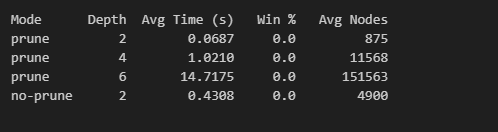

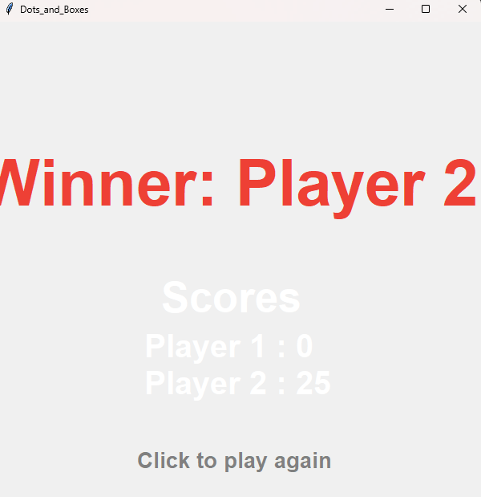

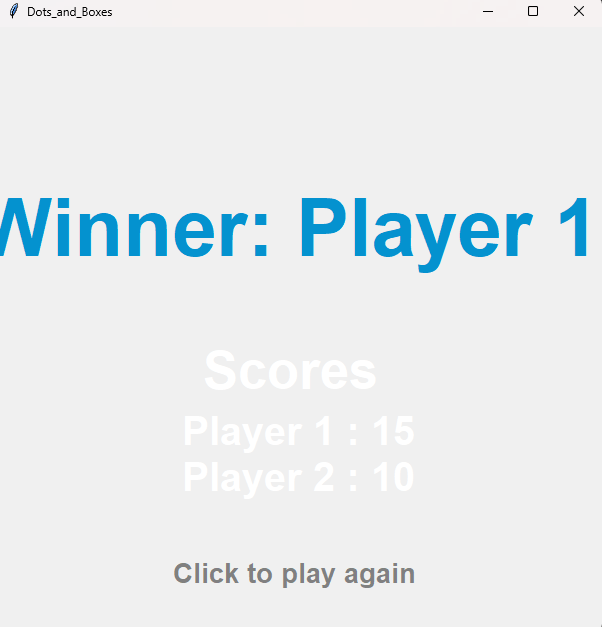

```python
from IPython.display import Image, display
display(Image(filename="images/Screenshot 2025-11-22 002403.png", width=1000))
display(Image(filename="images/Screenshot 2025-11-22 195528.png", width=750))
display(Image(filename="images/Screenshot 2025-11-22 221404.png", width=750))
```

## Questions

Question 1

در اوایل بازی عمق3-4 برای کارایی، و در اواخر بازی عمق 5-6 برای دقت بیشتر؛ به‌همراه محدودیت زمانی .

Question 2

ترتیب بررسی حرکات در آلفا–بتا بسیار تعیین‌کننده است: هرچه «حرکت‌های خوب» زودتر دیده شوند، کران‌ها سریع‌تر به‌روز می‌شوند و شاخه‌های بیشتری هرس می‌گردد؛

تحلیل روش _order_moves :

اول حرکت‌های تکمیل جعبه (که اغلب نوبت را حفظ می‌کنند)، سپس ایمن، و در آخر پرریسک (ایجاد سه‌لبه). این کار همگرایی کران‌ها را سرعت می‌دهد و جلوی واگذاری زنجیره به حریف را می‌گیرد. محدودیتش این است که فقط به اثر

فوری نگاه می‌کند؛ تفاوت نقشِ نوبت (ماکس/مین)، حفظ نوبت پس از امتیاز، تغییر تحرک و سرنخ‌های گذشته را لحاظ نمی‌کند

استراتژی بهبود: به‌جای سه سطل ثابت، برای هر حرکت یک امتیاز ترتیبی می سازیم که چند عامل را ترکیب کند: ۱) امتیاز فوری (تکمیل جعبه) و حفظ نوبت، ۲) تغییر تعداد خانه‌های سه‌لبه (کمتر بهتر)، ۳) تغییر تحرک بازیکن بعدی (کمتر برای حریف بهتر)، ۴) نقش نوبت (اگر نوبت

ماست، حرکاتِ نگه‌دارندهٔ نوبت وزن بیشتری بگیرند؛ اگر نوبت به حریف می‌رسد، در فاز زنجیره حرکاتِ واگذاریِ کنترل به حریف در اولویت پایین‌تری باشند)، ۵) سرنخ‌های آموخته‌شده از جست‌وجو مانند «مسیرِ اصلی»، «حرکتِ قاطع»، و سابقه/تاریخچهٔ حرکت‌ها.

Question 3

یعنی «میانگین تعداد حرکت‌های قانونی ممکن از هر وضعیت» در درخت بازی.

ابتدای بازی: همهٔ یال‌ها خالی‌اند؛ در شبکه نقطه، تعداد یال‌های آزاد است (مثلاً برای n=4 می‌شود 24)، پس شاخه‌زایی بالا است.

میانهٔ بازی: هرچه یال‌ها پر می‌شوند، حرکت‌های قانونی کم می‌شوند؛ ضمن اینکه بازیکنان برای ندادن «سه‌لبه» فقط سراغ حرکت‌های امن می‌روند، پس شاخه‌زاییِ مؤثر از تعداد حرکت‌های باقی‌مانده هم کمتر می‌شود.

انتهای بازی: زنجیره‌ها شکل می‌گیرد و بسیاری از حرکت‌ها «اجباری» می‌شوند؛ شاخه‌زاییِ مؤثر می‌تواند به نزدیکی 1 برسد (دنبالهٔ گرفتن‌های پیاپی).

نکتهٔ جست‌وجویی: ترتیب‌دهی خوبِ حرکت‌ها و هرس آلفا–بتا شاخه‌زاییِ مؤثر را باز هم کاهش می‌دهد و سرعت ارزیابی را بالا می‌برد.

Question 4

Alpha–beta pruning maintains two bounds while exploring the game tree: alpha (the best guaranteed value so far for the maximizing player) and beta (the best guaranteed value so far for the minimizing player). As you descend the tree, you update alpha at MAX nodes and beta at MIN nodes. If at any point a node’s prospective value can no longer improve the current bound (beta ≤ alpha), you prune the remaining siblings under that node, because even a perfect continuation there cannot beat what you already have elsewhere—thus you never lose the optimal move, only discard branches that are provably inferior.

Example on Dots and Boxes (2×2 boxes, i.e., 3×3 dots). At the root (MAX’s turn), alpha = −∞, beta = +∞, with two candidate moves a and b. Exploring a first: suppose a completes a box and keeps the turn; its children evaluate to, say, 5 and 4, so MAX backs up 5 and the root’s alpha becomes 5. Now explore b: b yields a state where it’s MIN’s turn; the first child of b evaluates to 3, so at that MIN node beta becomes 3. Since beta (3) ≤ alpha (5), you prune the rest of b’s children—no remaining line under b can ever produce a value higher than 5 for MAX. You’ve evaluated fewer nodes but preserved the same best move (a).

Question 5

چون باید درخت بازی را تا عمق از پیش تعیین‌شده بکاود و برای شاخه‌های فراوان ارزیابی انجام دهد، حتی وقتی پاسخ‌های حریف به‌طور میانگین تصادفی است. در این حالت، هزینهٔ مرتب‌سازی حرکت‌ها، ارزیابی اکتشافی و گسترش یکنواخت شاخه‌ها

بازده کاهنده دارد: دقت اضافیِ ناشی از تعمیق، با رفتار تصادفیِ حریف خنثی می‌شود، اما زمان محاسباتی به‌سرعت رشد می‌کند. جایگزین مناسب‌تر، «جست‌وجوی درختی با نمونه‌برداری تصادفی» است.

این روش به‌جای پیمایش یکنواخت، با چرخهٔ انتخاب، گسترش، شبیه‌سازی‌های سریع تصادفی و بازتاب نتیجه به بالا کار می‌کند و بودجهٔ زمان را روی شاخه‌های امیدبخش متمرکز می‌سازد. در مرحلهٔ انتخاب

از «شاخص اطمینان بالا» برای برقراری تعادل میان بهره‌برداری و اکتشاف استفاده می‌شود؛ چون حریف تصادفی است، ارزش حالت‌ها با همین شبیه‌سازی‌های سریع به‌خوبی تقریب زده می‌شود.

نتیجه این‌که با زمان کمتر، گره‌های کمتری دیده می‌شود، حرکت بهتری به‌دست می‌آید، و در بازی نقطه‌و‌جعبه نیز می‌توان شبیه‌سازی‌ها را کمی هدایت کرد (ترجیح تکمیل جعبه و پرهیز از سه‌لبه) تا کارایی بیشتر شود،

بی‌آن‌که هزینهٔ تعمیق کاملِ روش کمینه‌ـ‌بیشینه پرداخت شود.